# Class 5

May 10, 2017

## Today

## Agenda

- Review of homework
- Mapping with ggplot2
- Discussion of final exam
- Workflow
- Reproducible research
- Fun stuff
- Some "data management"
- Practice

## Homework review

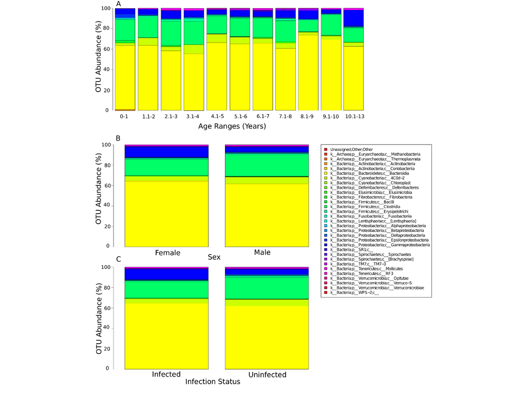

## Homework review

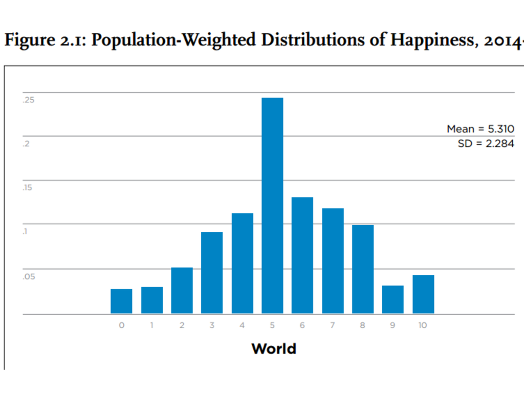

## Homework review

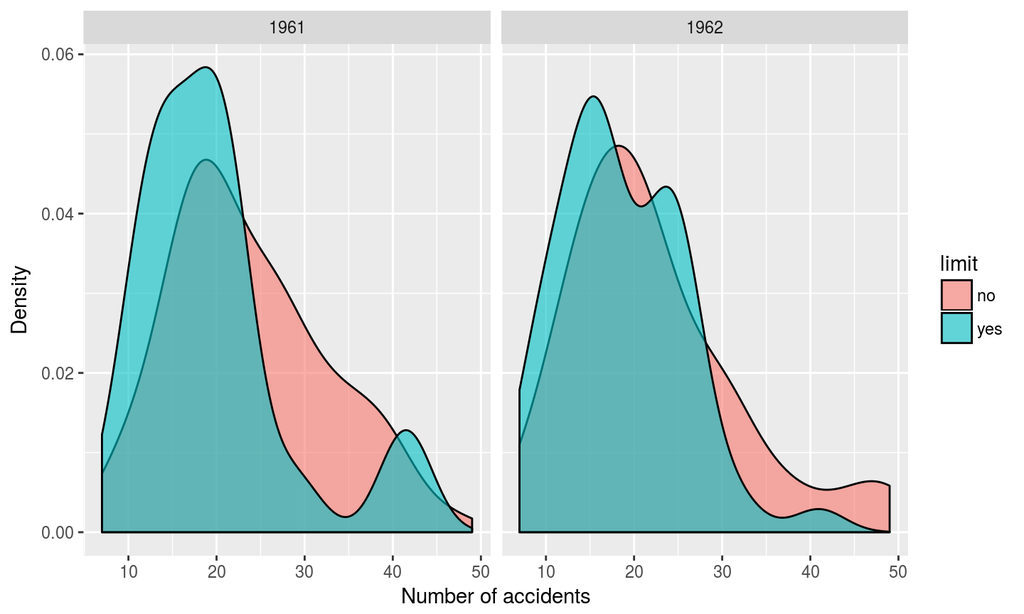

## Homework review

"If we compare the mean number of accidents for each day (for the 2 years), we see that we see that the trend in the number of accidents is always higher for those days with no speed limit. In consequence, it seems that the traffic policy doesn't have any impact on the number of accidents. So the president should probably apply another policy."

"I would not have any speed limit because there is no association between speed limit and reduction of accidents."

"If I were the president of Sweden I would definetely make sure there were speed limits, because, clearly there is a reduction in the number of daily accidents if there are speed limits in place."

"Despite being really annoying… Yes, I would.""

## Mapping with ggplot

We have previously made maps of Manhiça.

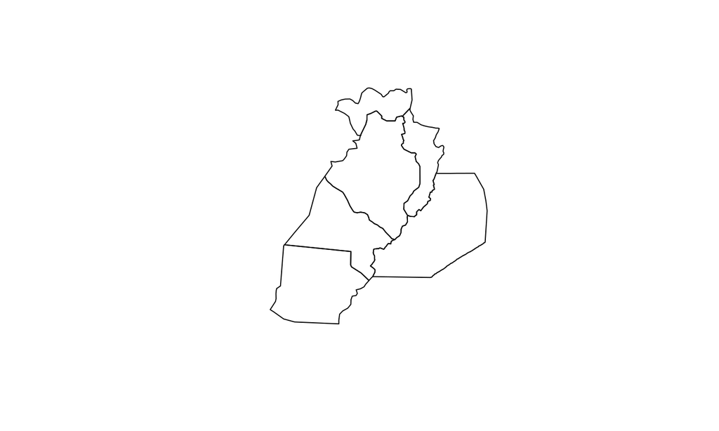

```r
library(cism)
library(sp)
library(ggplot2)
plot(man3)
```

## Mapping with ggplot

Now we're going to do it with ggplot.

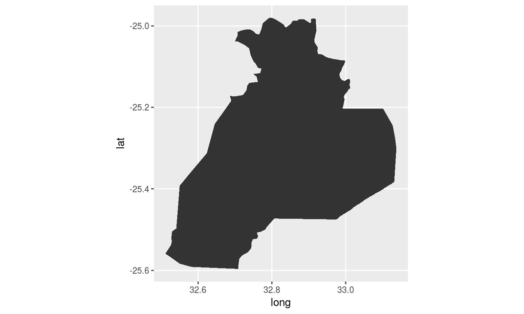

```r
ggplot(data = man3_fortified,
       aes(x = long,
           y = lat,
           group = group)) +
  geom_polygon() +
  coord_map()
```

## Practice

Make a map of Manhica using ggplot and then add points for the residents of the census. If you're feeling fancy, make the point size and color a reflection of a numberic and categorical variable.

## Installation

1. Remove `databrew` and re-install it.

```r
remove.packages('databrew')
devtools::install_github('databrew/databrew')
```

1. Make sure you have the following packages installed:
- googleVis
- gapminder
- wordCloud2

## Workflow

## Components of workflow

- Get data (acquisition)
- Modify data (cleaning)
- Analyze data (analysis)
- See data (visualization)
- Describe data (paper writing)

## Workflow

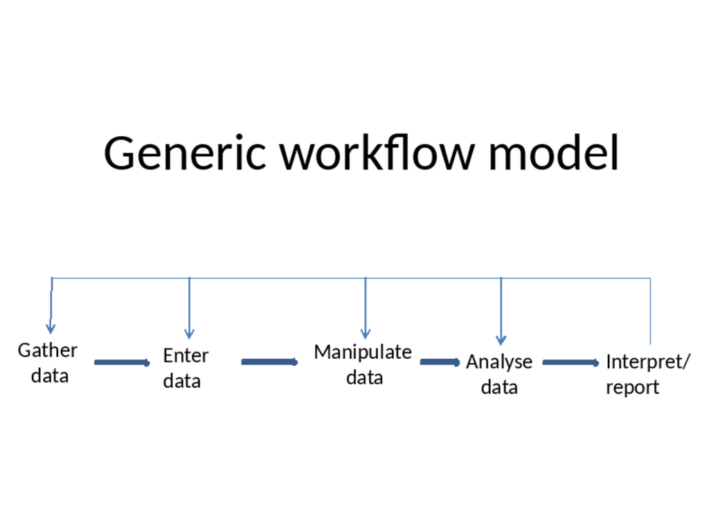

## Reproducibility

"Reproducibility is the ability of an entire analysis of an experiment or study to be duplicated, either by the same researcher or by someone else working independently."

(Wikipedia)

## How do we make our research reproducible?

- Everything must be documented.
- Everything must be automated.

## Workflow

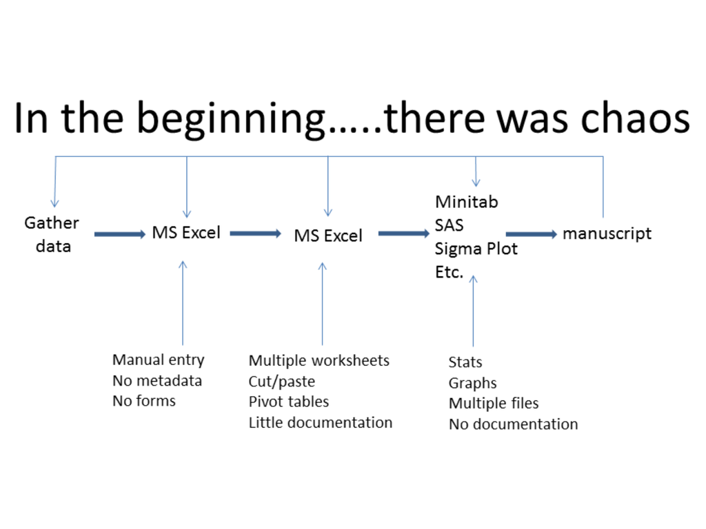

## Workflow

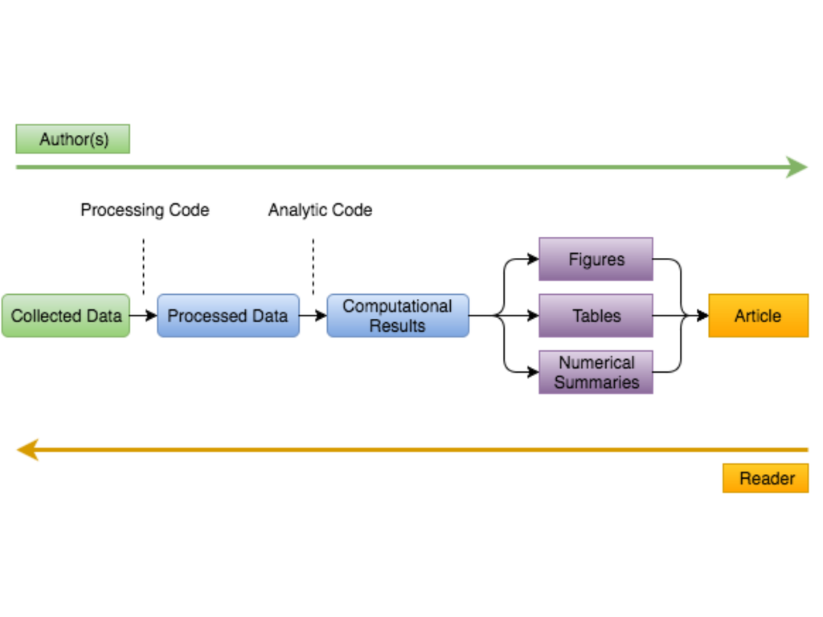

## Want to know more about reproducible research?

Take this course (it's free)

https://www.coursera.org/learn/reproducible-research

## Rather than talk about it, let's do it

## Survey

https://goo.gl/forms/TbzlWnId64PoxNwA3

## Review results

## Think of a question

What is a research question you would like to answer, based on the data we've just produced?

```r
sex, fingers, age, happiness, siblings, hand, drinks, beauty,
dancing, in_love, minutes_to_work, goat, mzn, money_or_sex,
describe_class, describe_self, describe_dream,
donkeys_or_tennis_balls, minutes_since_laugh, ther_country,
joe_or_brad, tattoos, describe_strength, describe_cism,
prison_for_money, where_born, seconds_teeth, joe_kilos
```

## Practice

1. Open a markdown file. Save it as "survey_report.Rmd".
2. Make an introduction section using `#`
3. Write an introduction.
4. Include in your introduction the number of people who took the survey.

## Practice

1. Make an R chunk.
2. Go to www.databrew.cc/survey.R. Copy that code
3. Make an R chunk, paste the code.

## Practice

1. Make sections for other parts of your paper (methods, results, etc.).
2. Write at least one sentence in each section.
3. In the "Results" section, make a chart showing age.
4. In the "Results" section, make a chart showing sex.
5. In the "Results" section, make a chart addressing your research question.

## Cheatsheet

https://www.rstudio.com/wp-content/uploads/2015/02/rmarkdown-cheatsheet.pdf

## Fun stuff

## Practice

## Geocoding

Let's geocode the locations of people's place of birth.

## Wordcloud

## Sentiment analysis

## GoogleVis

## googleVis

```r
library(googleVis)
library(gapminder)
```

## Get gapminder data

```r
gm <- gapminder
```

## Hans Rosling

[video not shown]

## Make some charts

## Make a `googleVis` chart

```r
library(googleVis)
g <- gvisMotionChart(data = gm,
                           idvar = 'country',
                     timevar = 'year',
                     sizevar = 'pop',
                     # date.format = '%Y',
                    xvar = 'gdpPercap',
                   colorvar = 'continent',

                           yvar = 'lifeExp')
# plot(g)
```